# Riemannian geometry

### **NOTES ON STATISTICS, PROBABILITY and MATHEMATICS**

### Riemannian Geometry:

From [this reference](https://youtu.be/BHKd6-IJgVI).

Riemannian geometry deals with intrinsic geometry on surfaces. The position vector at point P can be expressed on the basis of the extrinsic coordinates, or on the intrinsic coordinates on the manifold (the mesh of space-time). At each point of the manifold (referenced either extrinsically through the Cartesian system; or intrinsically via the curvilinear coordinate lines on the manifold), there will be a tangent vector space (and a dual). However, each point will have its own tangent vector space $T_P(M).$ Over the manifold, there will be a collection of vector spaces - one for each point, $T_x(M).$ A single vector can be selected at each point as a function of the coordinates (a function of space-time), creating a vector field:

$$\underbrace{X^\alpha(x)}_{\text{components as
f(space-time)}}\underbrace{\quad\partial _\alpha\quad}_{basis}\in\quad
T_x(M).$$

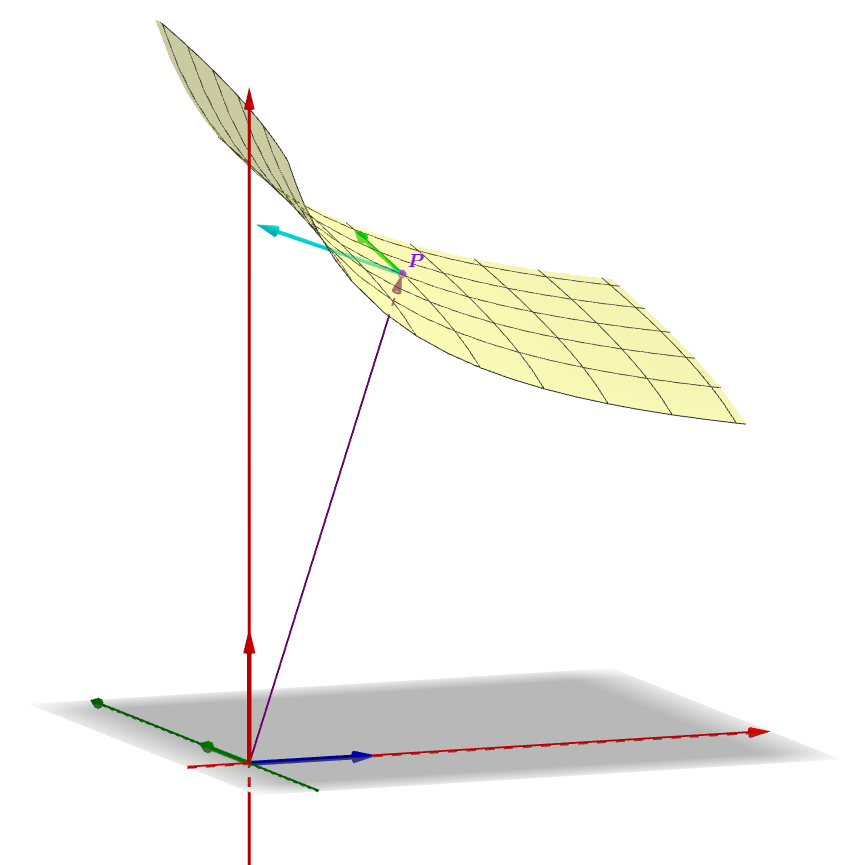

The basis of the tangent space will be $\frac{\partial}{\partial x^i}$ or $\partial x^i.$

The vectors in the tangent space and in the dual of the tangent space at every point are related through the metric $g_{\mu\nu}(x)\,dx^\mu\otimes dx^\nu,$ which is also a function of space time. This gives us an inner product at each point. For each vector in the tangent space $\left<\vec v,\;\right>\to \mathbb R,$ i.e. filling in the space with any other vector will produce a real number. Hence, $<v,;>V^*, $ linking the vector space with its dual.

However, we are still stuck at any particular point in space-time. As we move differentially along the manifold, the tangent plane changes since the vector space changes with every point. So we need a connector to relate vectors across the field.

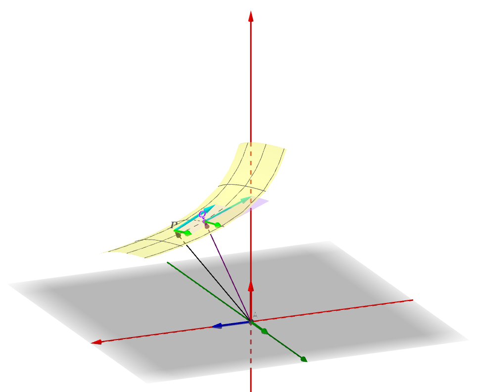

The change of coordinates between two points $P$ and $Q$ separated by a differential value $dx$ as expressed in the extrinsic coordinate system (position vectors from the origin) could be encapsulated with the Taylor series. The new extrinsic coordinates in the extrinsic plane will be $x+dx$ and $y+dy$, and the height will be a function of these two coordinates:

$$z(x+dx,y+dy)=z(x,y) + \frac{\partial
z}{\partial x} dx+ \frac{\partial z}{\partial y} dy$$

The distance vector $ds$ will be the difference between these two position vectors:

$$ds=z(x+dx,y+dy)- z(x,y)=\frac{\partial
z}{\partial x} dx+ \frac{\partial z}{\partial y} dy$$

and the square distance (changing now to covariant notation for covectors)

$$dx^2=ds \cdot
ds=g_{ij}\;dx^idy^j$$

with $g_{ij}$ constituting the **metric tensor.** In Cartesian coordinates the metric tensor is simply the identity matrix.

[XylyXylyX](https://youtu.be/hK3lt6ovgYc?t=16m59s) labels the vector that the vector field places at $x + \delta x,$ i.e. the position in space-time shifted by a small increment,

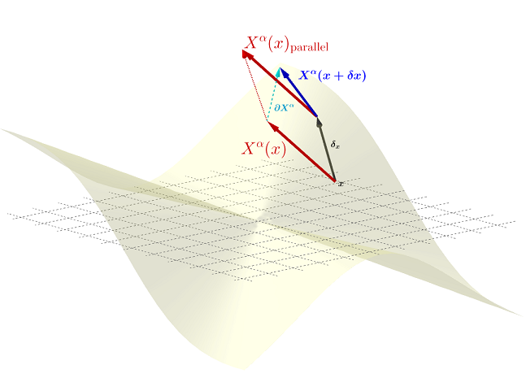

as $X^\alpha(x+\delta x),$ with a first grade [Taylor expansion](https://physics.stackexchange.com/q/361380/150551):

$$\begin{align}
X^\alpha\,(x + \delta x) &= \underbrace{X^\alpha (x)}_{\text{value
at }x}+\delta x^b\;\underbrace{\partial_bX^\alpha}_{\partial \text{wrt
compon's } \delta x}\\[2ex]
&=X^\alpha(x) + \delta x^b\;\frac{\partial X^\alpha}{\partial
x^b}\\[2ex]
&= X^\alpha(x) + \delta X^\alpha
\end{align}$$

#### [Covariant derivative](https://youtu.be/hK3lt6ovgYc):

Differential changes across a vector field will necessitate a way of moving across tangent spaces

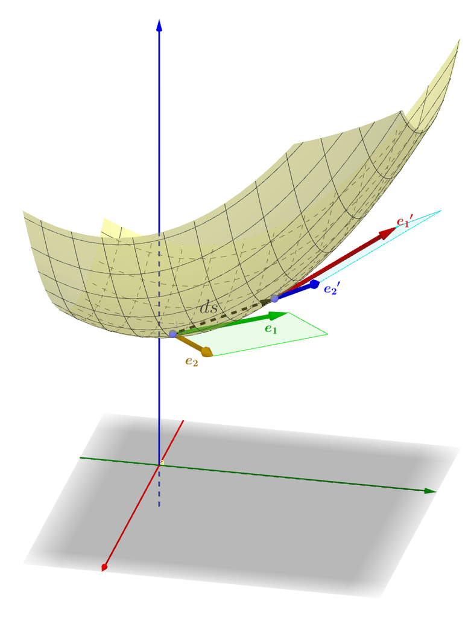

entailing a projection orthogonal to the parallelogram formed by $e_1$ and $e_2.$

$\frac{\partial \vec e_i}{\partial x^k}=\Gamma^j_{ki}\vec e_j+\text N^J_{ki}\; \vec n_j$

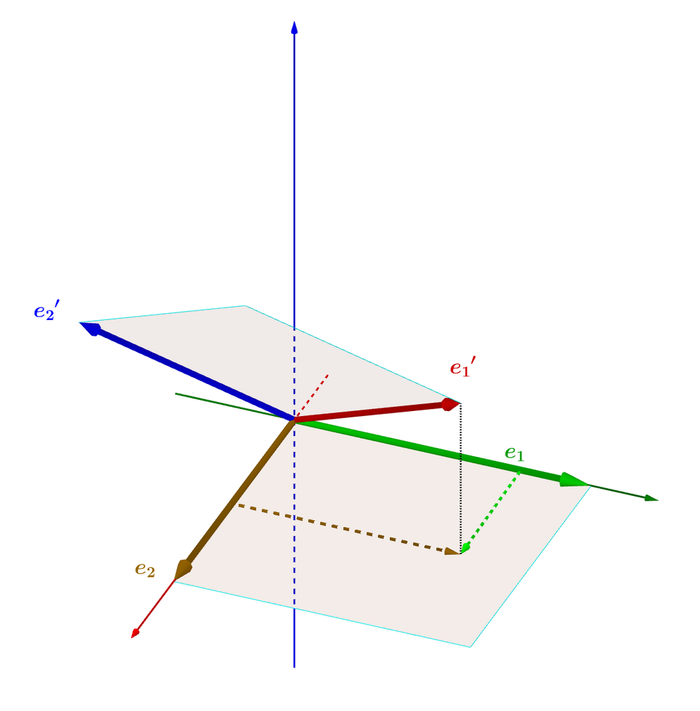

Defining a vector field $\vec V = V^i e_i$ using the basis $\vec e_1$ and $\vec e_1$ at point $P$ on the manifold, the derivative with respect to the coordinates $k=\{1,2\}$ will be be

$$\begin{align}
\frac{\partial \vec V}{\partial x^k}&=\left(\frac{\partial
V^i}{\partial x^k} \right)
\,\vec e_i \quad +\quad V^i\,\left(\frac{\partial e_i}{\partial
x^k}\right)\\[2ex]
&=
\left[\frac{\partial V^i}{\partial x^k}\,\vec e_i + V^i\Gamma^j_{ki}
\,\vec e_j\right]
\quad +\quad V^i\,\text{N}^j_{ki}\,n_j\\[2ex]
&=
\left[\frac{\partial V^i}{\partial x^k}\,\vec e_i + V^j\Gamma^i_{kj}
\,\vec e_i\right]
\quad +\quad V^i\,\text{N}^j_{ki}\,n_j\\[2ex]
&= \underbrace{\left[\frac{\partial V^i}{\partial x^k} +
V^j\Gamma^i_{kj} \right]}_{\text{covariant derivative}}\,\vec e_i
\quad +\quad V^i\,\text{N}^j_{ki}\,n_j\\[2ex]
\end{align}$$

$$D_k V^i= \frac{\partial V^i}{\partial
x^k} + V^j\Gamma^i_{kj}$$

with $\Gamma^i_{kj}$ corresponding to the Christoffel symbol, which is geometrically intepretable in the case of one single basis vector, i.e. $K=1$ as the projection of $e_1'$ on $e_1$ minus $e_1$, or $\Gamma^1_{11}dx^1\vec e_1.$ The projection of $e_1'$ on $e_2$ minus $e_2$ is $\Gamma^2_{11}dx1.$ Similarly, the projection of $e_2'$ on $e_1$ minus $e_1$ is $\Gamma^1_{12}dx^1$; and for $e_2'$ on $e_2,$ $\Gamma^1_{22}dx^1.$

This establishes the notion of a parallel vector in the translated point as:

$$\left(\frac{\partial \vec V}{\partial
x^K} \right)_{\vert\vert} = \left(D_k V^i\right)\,\vec e_i =
\left[\frac{\partial V^i}{\partial x^k}+\Gamma^i_{jk}V^j \right]\vec
e_i$$

[XylyXylyX](https://youtu.be/hK3lt6ovgYc?t=22m49s) talks about $X^\alpha(x)_{\vert\vert},$ (see third plot above) and defines

$$\bar \delta X^\alpha = X^\alpha(x)_{||}-
X^\alpha(x)$$

Since

$$X^\alpha(x+\delta x) = X^\alpha (x) +
\delta X^\alpha$$

and

$$X^\alpha(x)_{||}= X^\alpha(x) + \bar
\delta X^\alpha$$

the difference between the “parallel” vector to the original and the vector at a differential point along the vector field is going to be

$$X^\alpha (x+\delta x) - X^\alpha
(x)_{||}=\delta X^\alpha(x)- \bar \delta X^\alpha$$

and dividing by $\delta x$ we get the notion of a derivative (rate of change of a vector field), breaking the seal between the vector field at point $P$ and $Q.$

So we have

$$X^\alpha (x+\delta x) -
\underbrace{\left[X^\alpha(x) +\hat \delta
X^\alpha\right]}_{\text{parallel vec}}=\delta X^\alpha (x)- \bar \delta
X^\alpha$$

using the [Taylor expansion for the first term](https://physics.stackexchange.com/q/361380/150551):

$$X^\alpha(x) + \delta X^\alpha -
X^\alpha(x) - \bar\delta X^\alpha= \delta X^\alpha - \bar \delta
X^\alpha$$

which we want to divide by $\delta X$ to get the rate of change:

$$\begin{align}
\nabla X^\alpha&=\lim_{\delta X\to 0}\frac{\delta X^\alpha - \bar
\delta X^\alpha}{\delta X}\\[2ex]&= \lim_{\delta X\to 0}\frac{\delta
X^\alpha }{\delta X}-\lim_{\delta X\to 0} \frac{ \bar \delta
X^\alpha}{\delta X}\\[2ex]
&= \lim_{\delta X\to 0}\partial X^\alpha- \lim_{\delta X\to 0}\frac{
\bar \delta X^\alpha}{\delta X}
\end{align}$$
which is the **covariant derivative of the vector field $X$.**

In the limit we can expect $\delta X$ and $X^\alpha(x)$ to have a linear relation to $\bar \delta X^\alpha$. But since both $\delta X$ and $X^\alpha(x)$ have $4$ components, it will need to be linear in $16$ combinations of components. In comes $\Gamma^\alpha_{kj}$ or Christoffel symbol, as the multiplier for these pairwise linear relations:

$$\bar
\delta^\alpha=-\Gamma^\alpha_{kj}\,X^k(x)\,\delta x^j$$
The Christoffel symbol is not a tensor, but just components, and the parallel vector is

$$X^\alpha(x)_{\vert\vert}=X^\alpha(x)
-\Gamma^\alpha_{kj}\,X^k(x)\,\delta x^j$$

The Cristoffel symbol is a function of space-time:

$$\bar
\delta^\alpha=-\Gamma^\alpha_{kj}(x)\,X^k(x)\,\delta x^j$$

This is called the **CONNECTION**. And this connection comes from the **METRIC**.

The **covariant derivative** is thus expressed as

$$\begin{align}\nabla
X^\alpha&=\lim_{\delta X\to 0}\partial X^\alpha- \lim_{\delta X\to
0}\frac{ \bar \delta X^\alpha}{\delta X}\\[2ex]
&=\lim_{\delta X\to 0}\partial X^\alpha+ \lim_{\delta X\to
0}\Gamma^\alpha_{kj}(x)\,X^k(x)
\end{align}$$

which is stated as

$$\underbrace{\nabla_c
X^\alpha}_{(1,1)-\text{tensor}} =X^\alpha_{;c}=
X^\alpha_{||c}=\underbrace{\partial_c X^\alpha}_{\partial \text { of vec
field wrt components}} + \Gamma^\alpha_{kj}X^k$$

and it could be fully expressed as

$$X^\alpha_{;c}\,\partial_\alpha\otimes
dx^c$$

[Home Page](http://rinterested.github.io/statistics/index.html)

**NOTE: These are tentative notes on different topics for personal use - expect mistakes and misunderstandings.**